# Understanding Code

Week 2 of Data Science for NGA LTER REU Students

Liz Dobbins

NGA LTER / Axiom Data Science

2023-07-27

## Last Week

1. Open Science
2. Scripting/Programming/Code
3. Version Control
4. Data Life Cycle

## Why Coding?

- Code replicates processing steps
- Code reduces errors
- Documented code creates a record of processing steps
- Other people’s code = less work!
  - Don’t reinvent
  - Use standard libraries when possible

## How Do You Learn Coding?

- Learn the syntax
  - Tutorials
  - Documentation
- Practice
  - Really helps to have specific problem to solve
- Look at examples

> Programmers spend more time reading code than writing code

## What can cause problems?

- Short term memory
  - Limited to 2-6 items
  - Works better when recognize patterns
- Long term memory
  - Practice
  - Memorization
- Working Memory
  - Tricks

## Extraneous Cognitive Load

```python
6 + 8
```

vs

```python
a = 6
b = 8

z = a + b
```

## Trick 1: Comments

> Add human readable (non-executable) annotations within the code
- Document code purpose and design
- Should *not* need to explain every single step

## Trick 2: State Table

> Write down the values of variable for each step in the code

```python
x = 12
y = 5
z = y
y = x
x = z
```

| x | y | z |
| --- | --- | --- |
| 12 |  |  |
| 12 | 5 |  |
| 12 | 5 | 5 |
| 12 | 12 | 5 |
| 5 | 12 | 5 |

## Trick 3: Refactoring

> Transform code to “improve” the internal structure without changing the external behavior
- Make a copy and change it
- Replace syntax you don’t understand
- Perhaps revert changes once you figured it out (source control)

## Trick 4: Self-Documenting Code

> Write code using human-readable names and phrases that reflects the symbols’ meaning
- Descriptive variable names
- Repeated tasks should be functions (with descriptive names)

```python
def swap_values(first_value, second_value):
    holding = second_value
    second_value = first_value
    first_value = holding
    ...
```

## Trick 5: Tell your troubles to a Duck

> Or any little toy you have sitting on your desk

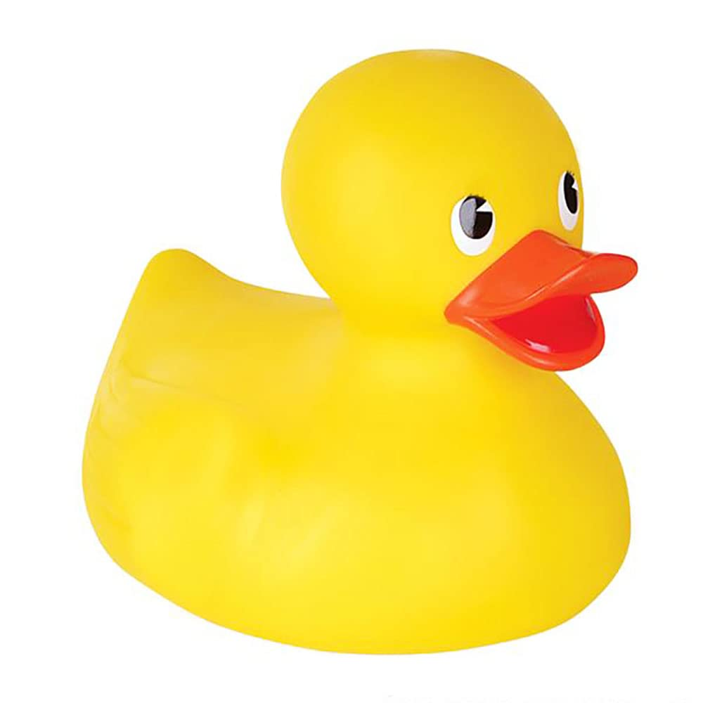

## Trick 6: Integrated Development Environment (IDE)

> Application that provides tools for programming
- Debugging
- Tracking variables
- Syntax checking
- Autocomplete

## Let’s Take a Break

[figure not shown]